# Gradient Forest - Genomic offset predictions

Author

Juliette Archambeau & Adélaïde Theraroz

Published

August 23, 2023

# Introduction

R code based on [the github repository](https://github.com/fitzLab-AL/geneticOffsetR) associated with Fitzpatrick et al. (2021).

# Data

> Genomic data

```r
# Population-based allele frequencies
# ===================================
geno <- read.csv(here("data/genomic_data/imputed_allele_frequencies_withoutmaf.csv"),
                 row.names = 1)

# SNP sets
# ========
cand <- readRDS(here("outputs/candidate_snps.rds")) %>%
  str_replace("[-]",".") # we change the name of the SNPs so that they are valid R column names
```

> Climatic data

```r
# Set of climatic variables
# =========================
clim_var <- c("bio1","bio12","bio15","bio3","bio4","SHM")


# Climatic data
# =============
# we scale the past and future climatic data at the location of the populations
# with the parameters (mean and variance) of the past climatic data.
source(here("scripts/functions/generate_scaled_clim_datasets.R"))
clim_dfs <- generate_scaled_clim_datasets(clim_var)
```

# Running GF models

```r
# Warning! Important to sort the SNP names, otherwise
  # the colors in the species (allele) cumulative plots
  # do not correspond to the right alleles
geno_sub <- geno %>% dplyr::select(all_of(sort(cand)))

gf_mod <- gradientForest(data.frame(clim_dfs$clim_ref[,-1], geno_sub),
                         predictor.vars=clim_var,
                         response.vars=colnames(geno_sub),
                         corr.threshold=0.5,
                         ntree=500,
                         trace=T)
```

Number of alleles for which the climatic variables have some predictive power: 73 SNPs.

We generate some plots to evaluate the GF models (stored in the files `GFplots.pdf`):

- **Predictor overall importance plots**. They show the mean accuracy importance and the mean importance weighted by SNPs $\mathcal{R}^2$.
- **Splits density plots**. They show the binned split importance and location on each gradient (spikes), kernel density of splits (blacklines), of observations (red lines) and of splits standardised by observations density (bluelines). Each distribution integrates to predictor importance. These show where important changes in the abundance of multiple alleles are occurring along the gradient; they indicate a composition change rate.
- **Species** (in our case alleles) **cumulative plots**. They show, for each SNPs, the cumulative importance distributions of splits improvement scaled by $\mathcal{R}^2$ weighted importance, and standardised by density of observations. These show cumulative change in the presence of individual allele, where changes occur on the gradient, and the alleles changing most on each gradient.
- **Predictor cumulative plots**. They show, for each predictor, the cumulative importance distributions of splits improvement scaled by $\mathcal{R}^2$ weighted importance, and standardised by density of observations, averaged over all SNPs. These show cumulative change in overall allelic composition, and where changes occur on the gradient.
- $\mathcal{R}^2$ **measure of the fit** of the random forest model for each SNPs.

The code to generate those plots comes from ‘Example analysis of biodiversity survey data with R package `gradientForest`’ by C. Roland Pitcher, Nick Ellis and Stephen J. Smith ([pdf available here](https://gradientforest.r-forge.r-project.org/biodiversity-survey.pdf)).

```r
# ==============================
# Functions to make the GF plots
# ==============================

# splits density plot
make_split_density_plot <- function(x){

  plot(x,plot.type="S",
       imp.vars=names(importance(x)),
       leg.posn="topright",
       cex.legend=1,
       cex.axis=1,
       cex.lab=1.2,
       line.ylab=0.9,
       par.args=list(mgp=c(1.5, 0.5,0),mar=c(3.1,1.5,0.1,1),omi = c(0.1, 0.3, 0.1, 0.1)))

  }

# predictor cumulative plot
make_predictor_cumulative_plot <- function(x){

  plot(x, plot.type="C",
       imp.vars=names(importance(x)),
       show.species=F,common.scale=T,
       cex.axis=1,
       cex.lab=1.5,
       line.ylab=1,
       par.args=list(mgp=c(1.5, 0.5,0),mar=c(2.5,1,0.1,0.5),omi=c(0, +0.3,0,0)))}


# species cumulative plot
make_species_cumulative_plot <- function(x){

  plot(x,
     plot.type="C",imp.vars=names(importance(x)),
     show.overall=F,legend=T,leg.posn="topleft",
     leg.nspecies=10,
     cex.lab=1,
     cex.legend=1,
     cex.axis=1,
     line.ylab=1,
     par.args=list(mgp=c(1.5, 0.5,0),mar=c(2.5,1,0.1,0.5),omi=c(0, +0.3,0,0)))
  }


# R2 measure of the fit of the random forest model for each species
make_performance_plot <- function(x, horizontal=FALSE){

    old.mar<-par()$mar
    par(mfrow=c(1,1),mar=old.mar+c(0,0,0,0))
    Ylab <- expression(R^2)

    perf <- importance(x, type="Species")
    n <- length(perf)
    if (horizontal)
      plot(perf, 1:n, las = 2, pch=19, axes=F, xlab="", ylab="")
    else
      plot(1:n, perf, las = 2, pch=19, axes=F, xlab="", ylab="")
    axis(labels= names(perf),side=1+horizontal,at=1:n, cex.axis=0.7, padj=0,las=2)
    axis(side=2-horizontal, cex.axis=1)
    mtext(Ylab,side=2-horizontal,line=2)
    title("Overall performance of random forests over loci")
    abline(h = 0, lty = 2)
    box()
    par(mar=old.mar)

}

# ===============================================
# Generate the GF plots for the Github repository
# ===============================================
pdf(here(paste0("figs/GF/GFplots.pdf")), width=12,height=8)

# Overall importance plot
plot(gf_mod, plot.type="Overall.Importance")

# splits density plot
make_split_density_plot(x=gf_mod)

# species cumulative plot
make_species_cumulative_plot(x=gf_mod)

# predictor cumulative plot
make_predictor_cumulative_plot(x=gf_mod)

# R2 measure of the fit of the random forest model for each species
make_performance_plot(x=gf_mod)

dev.off()
```

# GO predictions

```r
go <- lapply(clim_dfs$clim_pred, function(clim_pred){

ref_pred <- predict(gf_mod) # predictions under current climates
fut_pred <- predict(gf_mod, as.data.frame(clim_pred[,clim_var])) # predictions under future climates


lapply(1:nrow(ref_pred), function(x, ref_pred, fut_pred){
    as.numeric(pdist(ref_pred[x,],  fut_pred[x,])@dist)}, fut_pred=fut_pred, ref_pred=ref_pred) %>%
  unlist()

})
```

## Relationship with Euclidean distance

```r
source(here("scripts/functions/make_eucli_plot.R"))

# Calculate the Euclidean climatic distance
list_dist_env <- clim_dfs$clim_pred %>% lapply(function(clim_pred){

Delta = clim_dfs$clim_ref %>% dplyr::select(any_of(clim_var)) - clim_pred %>% dplyr::select(any_of(clim_var))
dist_env = sqrt( rowSums(Delta^2) )

})

# Main gene pools (for the figures)
gps <- readRDS(here("data/genomic_data/main_gp_info.rds"))[[1]] %>%
  arrange(Population)
```

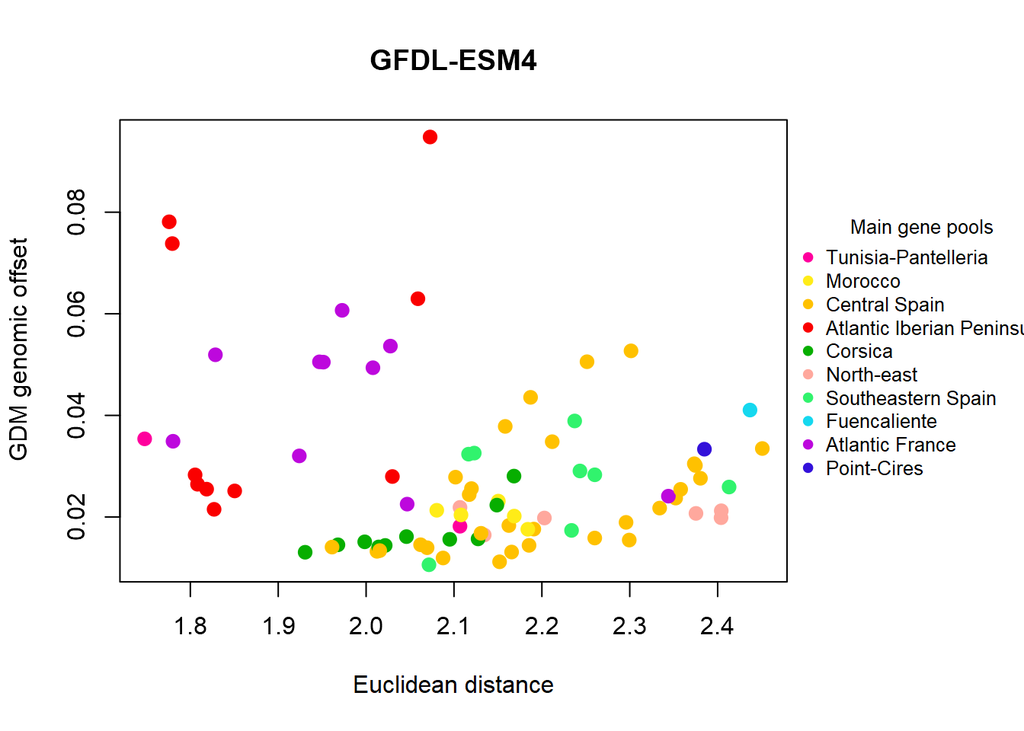

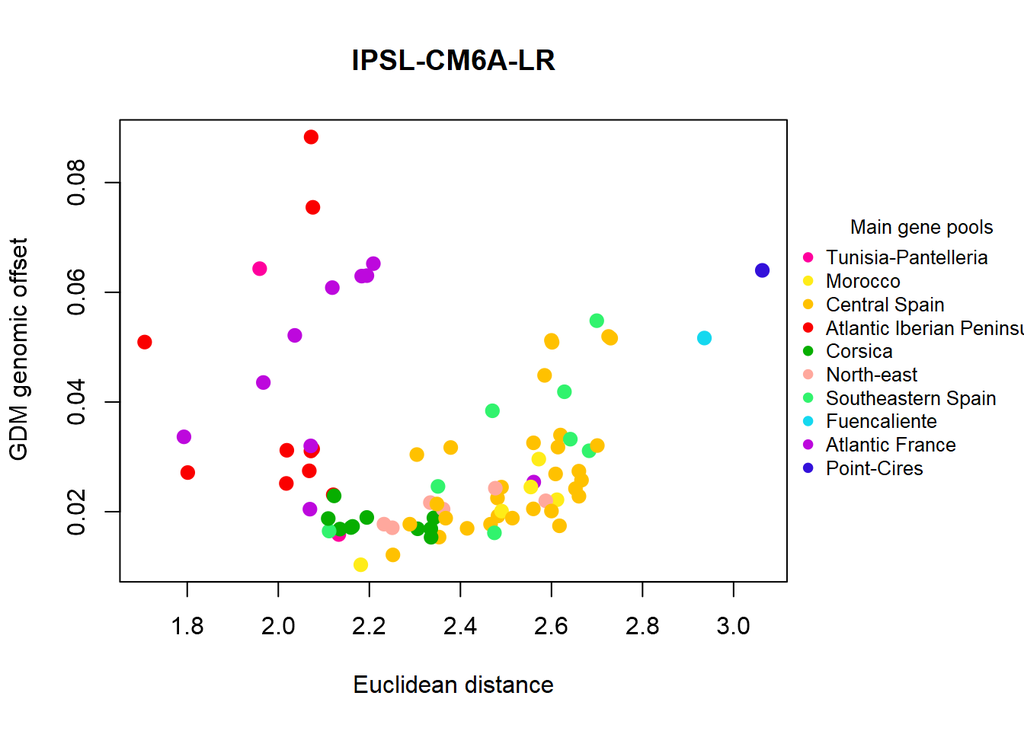

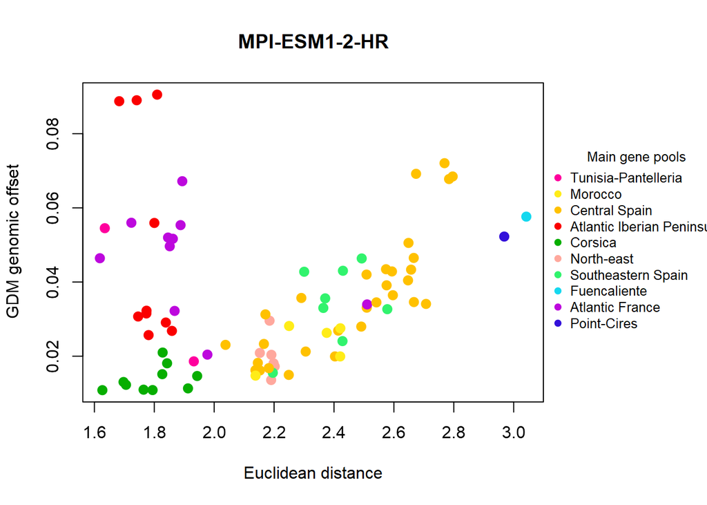

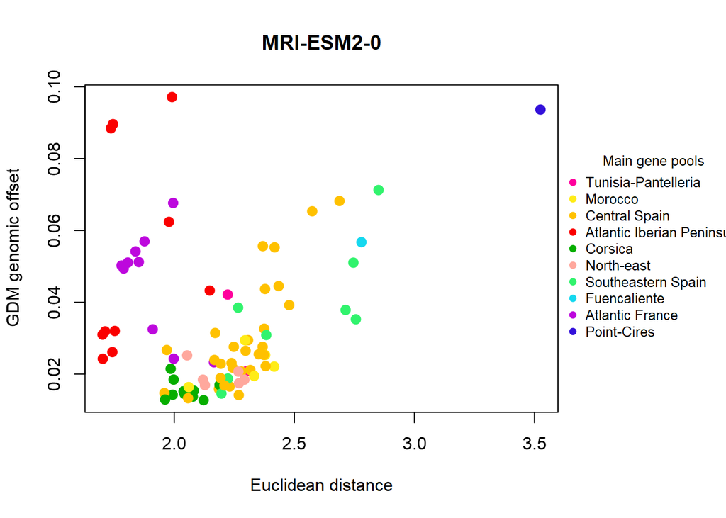

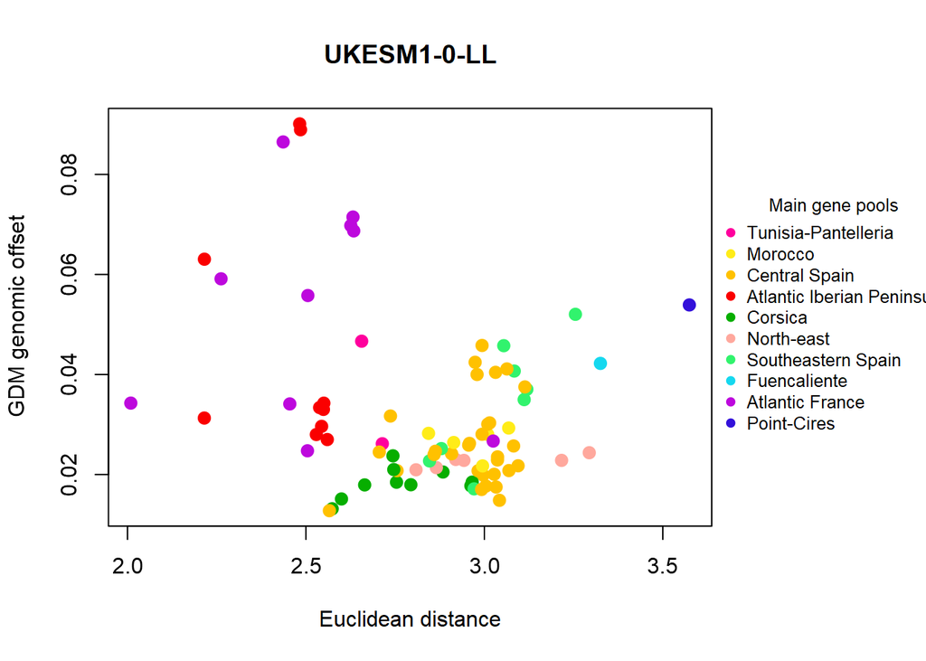

```r
par(mar=c(5.1, 4.1, 4.1, 8.1), xpd=TRUE)

lapply(names(list_dist_env), function(gcm){

make_eucli_plot(
  X = list_dist_env[[gcm]],
  Y = go[[gcm]],
  colors = gps$main_gp_pop_color,
  color_names = gps$main_gp_pop,
  ylab = "GDM genomic offset",
  inset=c(-0.4,0),
  legend_position="right",
  plot_title = gcm)

})
```

### Maps

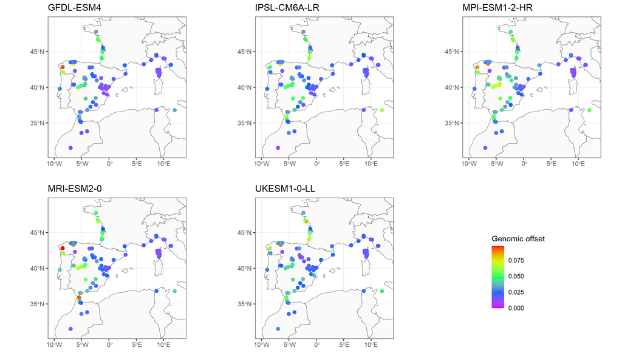

```r
# Function to make the genomic offset maps
source(here("scripts/functions/make_go_map.R"))

# Population coordinates
pop_coord <- read_csv(here("data/selected_populations_GOanalyses.csv"), show_col_types = FALSE) %>%
  dplyr::select(pop ,longitude, latitude)

# Find minimum and maximum values of genomic offset for the maps
go_limits <- lapply(names(list_dist_env), function(gcm){go[[gcm]]}) %>%  unlist() %>% range()
# The minimum GO value is very very small, almost zero, so we fix it to zero.
go_limits[[1]] <- 0


# Generate the maps for each set of SNPs and each GCM
go_maps <- lapply(names(list_dist_env), function(gcm){

make_go_map(dfcoord=pop_coord,
            gcm=gcm,
            go=go,
            go_limits=go_limits,
            point_size = 2)

})

legend_maps  <- get_legend(go_maps[[1]])

go_maps <- lapply(go_maps, function(y) y + theme(legend.position = "none"))

go_maps$legend_maps <- legend_maps

go_maps <- plot_grid(plotlist=go_maps)

# We can save the figures for the Supplementary Information
ggsave(here("figs/GF/GOMaps_PopLocations_SI.pdf"), go_maps, width=10,height=6, device="pdf")

go_maps
```

Let’s average the predictions across the five GCMs and generate a map.

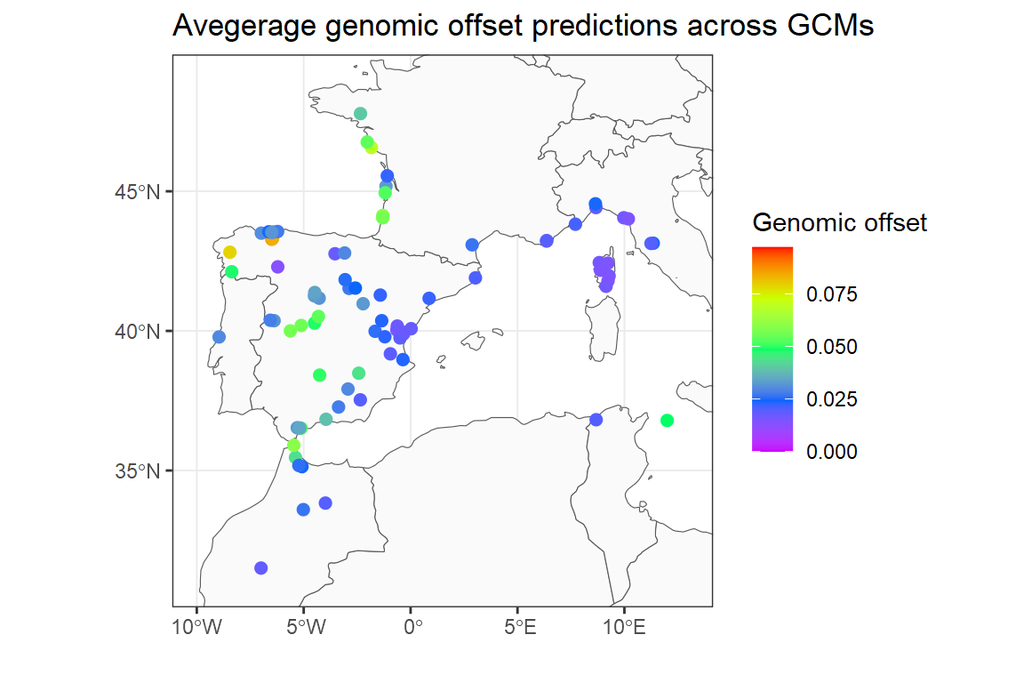

```r
go_mean <- go %>%
  bind_rows() %>%
  mutate(go_mean=rowMeans(.)) %>%
  pull(go_mean)
go_mean <- list("Avegerage genomic offset predictions across GCMs" = go_mean)

p <- make_go_map(dfcoord=pop_coord,
            gcm="Avegerage genomic offset predictions across GCMs",
            go=go_mean,
            go_limits=go_limits,
            point_size = 2)

# We can save the figure
ggsave(here("figs/GF/GOMaps_PopLocations_Avg.pdf"), p, width=6,height=4, device="pdf")

p
```

## References

Fitzpatrick, Matthew C, Vikram E Chhatre, Raju Y Soolanayakanahally, and Stephen R Keller. 2021. “Experimental Support for Genomic Prediction of Climate Maladaptation Using the Machine Learning Approach Gradient Forests.” *Molecular Ecology Resources*.